# Homework 3

## 1.3 Exercise 5.3

Apply a seasonal naïve method to the quarterly Australian beer production data from 1992. Check if the residuals look like white noise, and plot the forecasts. The following code will help.

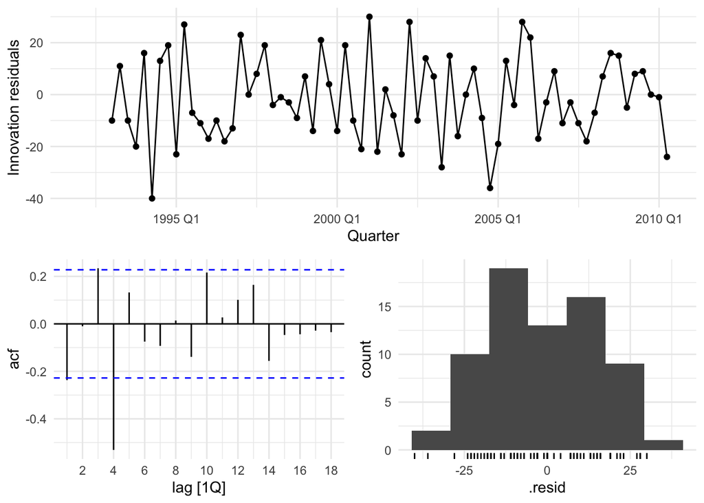

```r
# Extract data of interest
recent_production <- aus_production |>
  filter(year(Quarter) >= 1992)

# Define and estimate a model
fit <- recent_production |>
  model(SNAIVE(Beer))

# Look at the residuals
fit |> gg_tsresiduals()
```

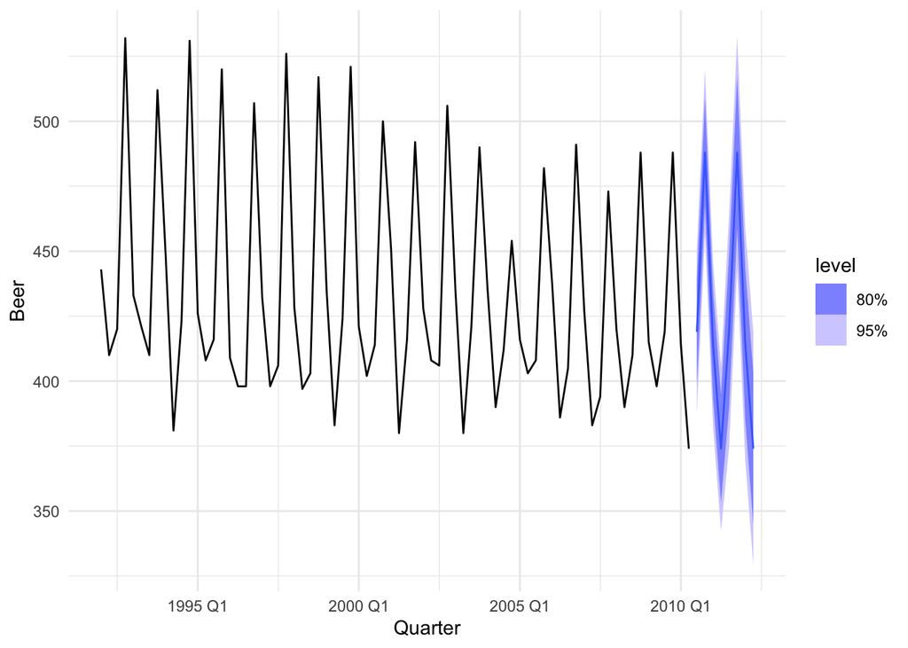

```r
# Look at some forecasts
fit |> forecast() |> autoplot(recent_production)
```

What do you conclude?

## 1.4 Exercise 5.4

Repeat the previous exercise using the Australian Exports series from `global_economy` and the Bricks series from `aus_production`. Use whichever of `NAIVE()` or `SNAIVE()` is more appropriate in each case.

### 1.4.1 Australian Exports

Using a naive model for the Australian exports, we get a very well distributed set of residuals, normally distributed and a mean of zero. While the range of forecast values is wide, the naive method does a good job of extracting the available signal.

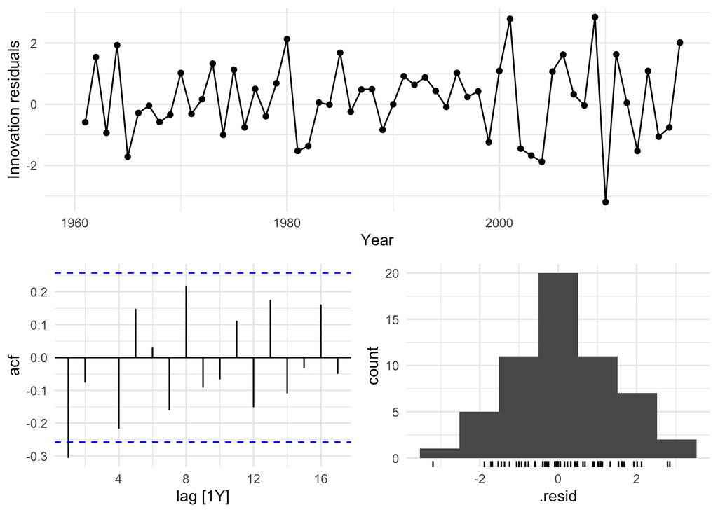

```r
#
aus_exports <- tsibbledata::global_economy |>
  select(Year, Exports) |>
  filter(Country == "Australia")

# Define and estimate a model
aus_exports_fit <- aus_exports |>
  model(NAIVE())

# Look at the residuals
aus_exports_fit |> gg_tsresiduals()
```

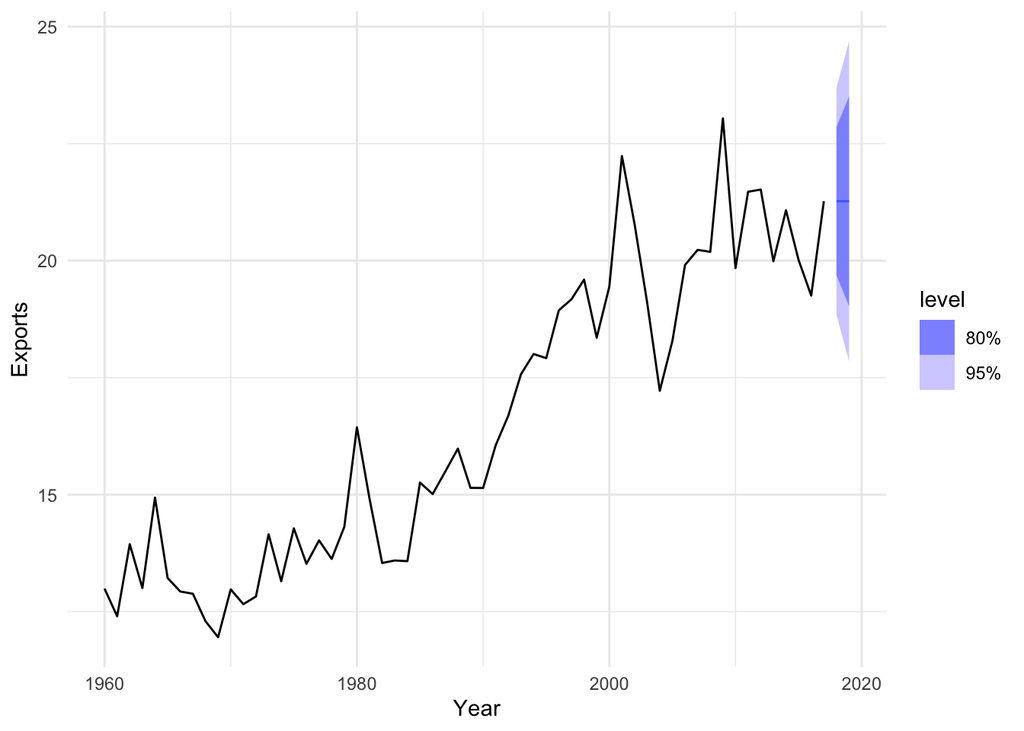

```r
# Look at some forecasts
aus_exports_fit |> forecast() |> autoplot(aus_exports)
```

### 1.4.2 Bricks

Neither naive (not pictured) nor seasonal naive seem to do particularly well for the brick dataset. While technically our residuals are centered around zero, the ACF and residual plot indicates to me there is some additional level of seasonality that this naive model is failing to capture. Seeing the ACF cycle and the patterns in the residuals plot, I would be confident that better forecasting performance could be achieved with a model that could better capture intra-season nuances.

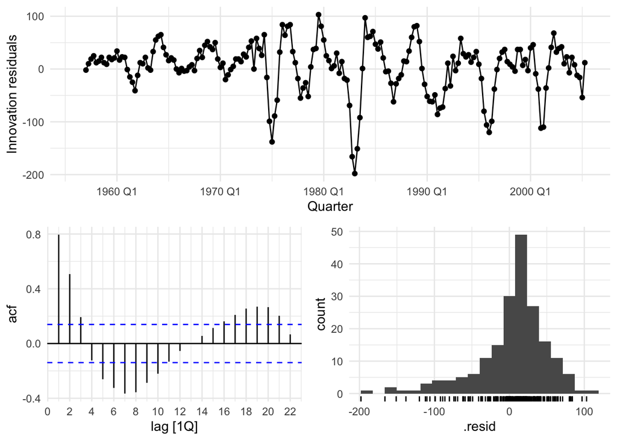

```r
# Define and estimate a model
bricks_fit <- bricks |>
  model(SNAIVE())

# Look at the residuals
bricks_fit |> gg_tsresiduals()
```

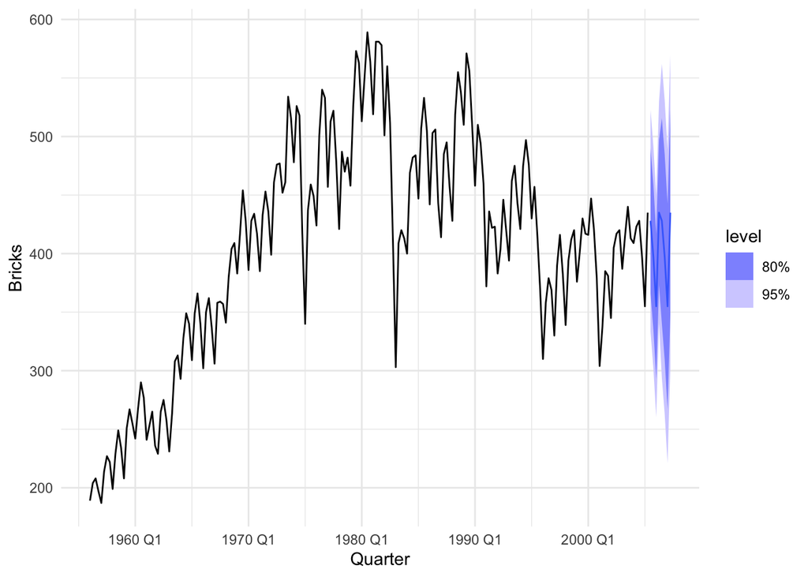

```r
# Look at some forecasts
bricks_fit |> forecast() |> autoplot(bricks)
```

## 1.5 Exercise 5.7

```r
# Initiate "myseries" from prior exercise
set.seed(42)

myseries <- aus_retail |>
  filter(`Series ID` == sample(aus_retail$`Series ID`,1))
```

For your retail time series (from Exercise 7 in Section 2.10):

1. Create a training dataset consisting of observations before 2011 using

```r
myseries_train <- myseries |> filter(year(Month) < 2011)
```

2. Check that your data have been split appropriately by producing the following plot.

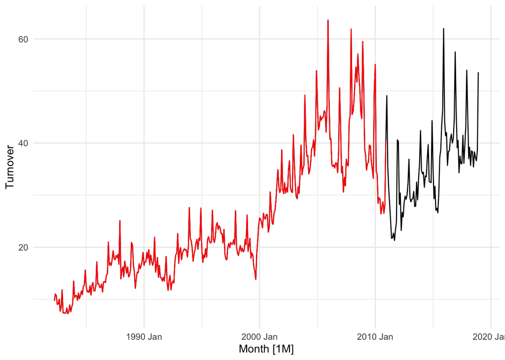

```r
autoplot(myseries, Turnover) +
  autolayer(myseries_train, Turnover, colour = "red")
```

3. Fit a seasonal naïve model using `SNAIVE()` applied to your training data (`myseries_train`).

```r
fit <- myseries_train |> model(SNAIVE(Turnover))
```

4. Check the residuals.

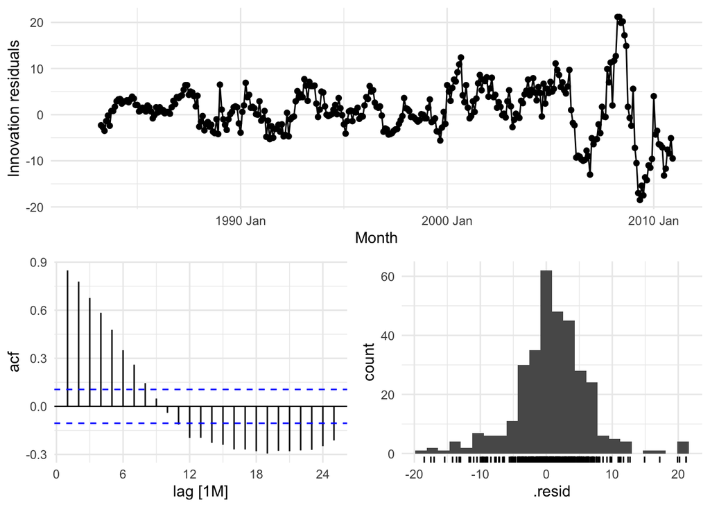

```r
fit |> gg_tsresiduals()
```

Do the residuals appear to be uncorrelated and normally distributed?

The residuals are normally distributed, however they are not uncorrelated - the ACF graph shows that very few months are within statistical expectations for random correlation, which tells us there is more signal to be uncovered in this data.

5. Produce forecasts for the test data

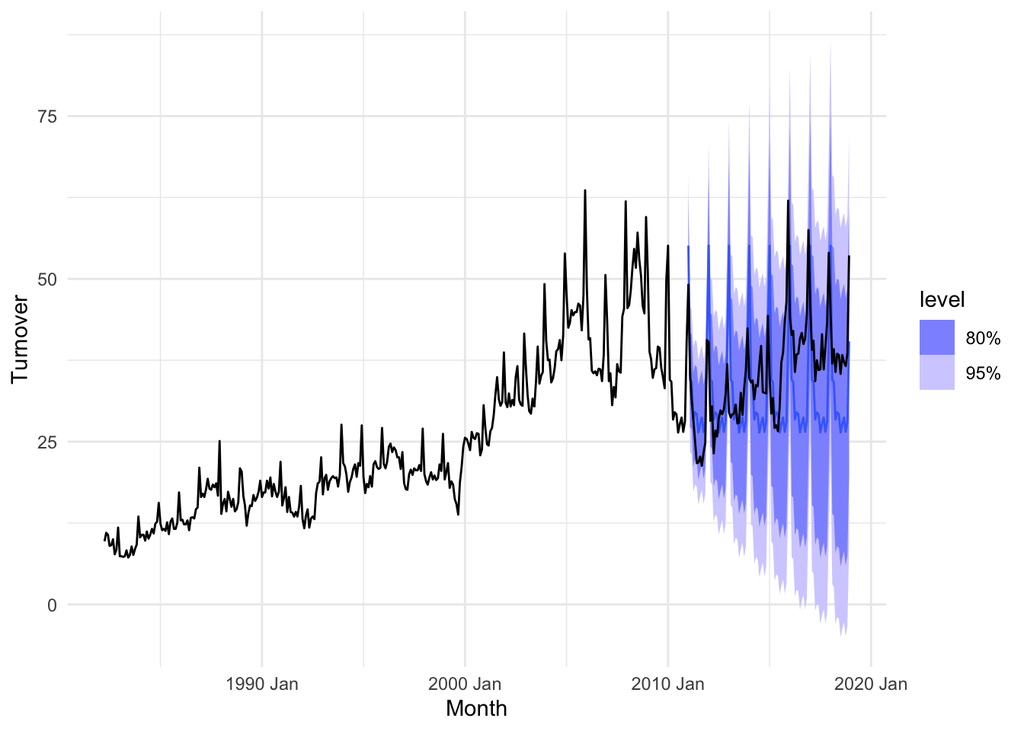

```r
fc <- fit |> forecast(new_data = anti_join(myseries, myseries_train))
fc |> autoplot(myseries)
```

6. Compare the accuracy of your forecasts against the actual values.

```r
fit |> accuracy()
```

```
# A tibble: 1 × 12
  State    Industry .model .type    ME  RMSE   MAE   MPE  MAPE  MASE RMSSE  ACF1
  <chr>    <chr>    <chr>  <chr> <dbl> <dbl> <dbl> <dbl> <dbl> <dbl> <dbl> <dbl>
1 Western… Newspap… SNAIV… Trai… 0.838  5.67  4.09  2.49  16.0     1     1 0.849
```

```r
fc |> accuracy(myseries)
```

```
# A tibble: 1 × 12
  .model    State Industry .type    ME  RMSE   MAE   MPE  MAPE  MASE RMSSE  ACF1
  <chr>     <chr> <chr>    <chr> <dbl> <dbl> <dbl> <dbl> <dbl> <dbl> <dbl> <dbl>
1 SNAIVE(T… West… Newspap… Test   3.04  9.11  7.34  6.06  19.9  1.79  1.61 0.513
```

7. How sensitive are the accuracy measures to the amount of training data used?